# Response to Muddy Points

Lecture: Analysis of Variance (ANOVA) (Week 9, Day 2)

Author

Emile

Published

March 5, 2026

# Overview

Thank you for the great feedback! The pace looks excellent — about 96% of you rated it “about right,” with no one finding it too fast. Several of you highlighted the R coding walkthrough and the ANOVA review as particularly clear, which is encouraging.

**Note**

You do not need to read every section below. Each heading addresses a specific muddy point raised in class. Feel free to focus on the ones most relevant to you.

# Why can’t we skip the ANOVA and go straight to post-hoc testing?

> *“Why can’t we skip the ANOVA and go straight to the post-hoc testing?”*

This is a really good question and it gets at something important about how statistical testing is designed to work.

**The short answer:** post-hoc tests are designed to be used *after* a significant omnibus test. Skipping the ANOVA and going directly to pairwise comparisons doesn’t save you from the multiple comparisons problem — it just removes the protection that ANOVA provides.

**The longer explanation:** Recall from the slides why we can’t just run all pairwise t-tests in the first place. With $k = 3$ groups, there are $m = 3$ pairwise comparisons, and the probability of at least one false positive inflates to:

$$P(\text{at least one false positive}) = 1 - (1 - \alpha)^m = 1 - (0.95)^3 \approx 0.14$$

That’s 14%, not 5%. ANOVA solves this by testing all groups *simultaneously* with a single test — one F-statistic, one p-value, one $\alpha$.

Post-hoc procedures like Tukey’s HSD are specifically designed to control error *after* the omnibus ANOVA has already flagged a significant result. The logic is sequential:

1. **ANOVA asks:** “Is there *any* evidence that at least one group mean differs?” (omnibus test)
2. **Post-hoc asks:** “Given that something is going on, *which specific pairs* are driving it?” (targeted follow-up)

If you skip step 1 and go directly to Tukey HSD, you are implicitly running post-hoc comparisons regardless of whether the overall evidence warrants it. This undermines the error-rate control that makes Tukey HSD valid — it was derived under the assumption that you passed the omnibus gate first.

**An analogy:** Think of it like a screening test followed by a diagnostic test in clinical practice. A positive screening result is what *justifies* running the more specific diagnostic. You wouldn’t skip the screening and run diagnostics on everyone — that would be expensive, produce unnecessary false positives, and undermine the purpose of the diagnostic’s design.

**The practical takeaway**

The standard workflow is:

1. Run ANOVA → if $p < \alpha$, proceed to post-hoc
2. If $p \geq \alpha$, stop — there is insufficient evidence that any pair differs, so post-hoc comparisons are not warranted

There are situations in which researchers state a small number of *a priori* comparisons before collecting data, in which case they can go directly to those planned contrasts without the omnibus ANOVA. But that is a more advanced scenario that requires pre-registration of hypotheses. For the standard “compare all groups” situation, ANOVA first is the right workflow.

# The F-statistic

> *“f statistic”*

I’ll keep this focused — the F-statistic is a ratio of two estimates of variability:

$$F = \frac{MSG}{MSE} = \frac{\text{between-group variability}}{\text{within-group variability}}$$

The intuition is straightforward:

- **Under $H_0$** (all group means equal): the group means scatter around the grand mean about as much as individual observations scatter around their group means. The ratio is close to 1.
- **Under $H_A$** (at least one mean differs): the group means are more spread out than random chance would produce. The ratio is greater than 1 — potentially much greater.

So a large F-statistic is evidence *against* $H_0$. The p-value is always the **upper tail** of the F-distribution, because we only care about F being surprisingly large. An F-statistic near zero would actually be *less* surprising than F = 1 under $H_0$.

The exact shape of the F-distribution depends on two degrees-of-freedom parameters — $df_1 = k - 1$ (between groups) and $df_2 = N - k$ (within groups) — which brings us directly to the ANOVA table.

# The ANOVA table: a guided walkthrough

> *“I’m still really confused on the ANOVA table (slide #14) and the significance of each component and how they fit into the whole test and their relationship to the F statistic”*

This is the right thing to be confused about — the ANOVA table packs a lot of information into a small space. Let me walk through it component by component, building from left to right.

Here is the table again for reference:

| Source | SS | df | MS | F |
| --- | --- | --- | --- | --- |
| Between groups (Model) | SSG | $k-1$ | $MSG = SSG/(k-1)$ | $F = MSG/MSE$ |
| Within groups (Error) | SSE | $N-k$ | $MSE = SSE/(N-k)$ |  |
| Total | SST | $N-1$ |  |  |

## Column 1: Source

The table partitions the total variation in the data into two pieces:

- **Between groups (SSG):** how much the group means vary *from each other* (and from the grand mean)
- **Within groups (SSE):** how much individual observations vary *within* their own group

The Total row is the sum of the two pieces: $SST = SSG + SSE$.

## Column 2: SS (Sums of Squares)

Each sum of squares is literally a sum of squared deviations — it quantifies a specific kind of variability.

- **SSG** measures how far the group means are from the grand mean, weighted by group size
- **SSE** measures how far individual observations are from their own group mean
- **SST** measures how far every observation is from the grand mean

These correspond to the three panels in the visualization from class:

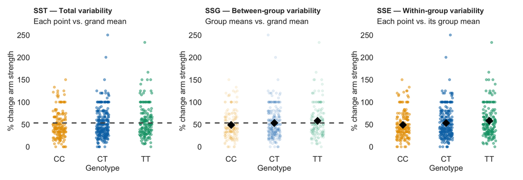

$$SST = SSG + SSE$$

## Column 3: df (Degrees of Freedom)

Degrees of freedom are the number of “free” pieces of information available to estimate each component. You can think of them roughly as the number of independent comparisons being made.

- **Between groups:** $df_G = k - 1$. With $k = 3$ groups (CC, CT, TT), we have $df_G = 2$. We “use up” one df to estimate the grand mean, leaving $k - 1$ free comparisons among group means.
- **Within groups:** $df_E = N - k$. Within each group we estimate one mean, so we lose one df per group. With $N$ total observations and $k$ groups, $df_E = N - k$.
- **Total:** $df_T = N - 1$, which is simply $df_G + df_E = (k-1) + (N-k)$.

For the FAMuSS example: $k = 3$, $N = 595$, so $df_G = 2$ and $df_E = 592$.

## Column 4: MS (Mean Squares)

Here is the key step people often miss. **Sums of squares are not directly comparable to each other** because SSG and SSE were built by adding up different numbers of squared terms. A larger SS might just mean more terms were summed, not that variability is genuinely greater.

Mean squares fix this by converting sums to *averages* — dividing each SS by its degrees of freedom:

$$MSG = \frac{SSG}{k-1} \qquad MSE = \frac{SSE}{N-k}$$

Now MSG and MSE are on the same scale: they are both average squared deviations, and they can be meaningfully compared as a ratio.

**Concrete interpretation for FAMuSS:**

```r
famuss_aov <- aov(ndrm.ch ~ actn3.r577x, data = famuss)
summary(famuss_aov)
```

```
             Df Sum Sq Mean Sq F value Pr(>F)
actn3.r577x   2   7043    3522   3.231 0.0402 *
Residuals   592 645293    1090
---
Signif. codes:  0 '***' 0.001 '**' 0.01 '*' 0.05 '.' 0.1 ' ' 1
```

From this output, you can read off all five columns directly. The SSG is in the `Sum Sq` row for `actn3.r577x`, SSE is in the `Residuals` row, and so on.

## Column 5: F

The F-statistic is simply the ratio of the two mean squares:

$$F = \frac{MSG}{MSE}$$

This is the whole test in one number. It answers the question: **is the between-group variability larger than we would expect from within-group variability alone?**

- If $F \approx 1$: between-group and within-group variability are about the same — no evidence the means differ
- If $F \gg 1$: between-group variability far exceeds what’s happening within groups — evidence that at least one mean differs

The p-value is then the area in the upper tail of the F-distribution with $df_1 = k-1$ and $df_2 = N-k$.

## Putting it all together

Here is the full chain of reasoning in one diagram:

$$\underbrace{SST}_{\text{Total variation}} = \underbrace{SSG}_{\substack{\text{Between-group}\\\text{variation}}} + \underbrace{SSE}_{\substack{\text{Within-group}\\\text{variation}}}$$

$$\downarrow \text{ divide by } df$$

$$MSG = \frac{SSG}{k-1} \qquad MSE = \frac{SSE}{N-k}$$

$$\downarrow \text{ take the ratio}$$

$$F = \frac{MSG}{MSE} \xrightarrow{\text{compare to } F\text{-distribution}} p\text{-value}$$

**A way to remember it**

Think of the F-statistic as a signal-to-noise ratio:

- **MSG** is the *signal* — the systematic differences between group means
- **MSE** is the *noise* — the natural variability within groups that you can’t control

A large F means the signal is strong relative to the noise. That is evidence that the group differences are real, not just random fluctuation.

# Summary

- **Why ANOVA before post-hoc:** ANOVA controls the Type I error rate globally before any pairwise comparisons are made. Post-hoc procedures (like Tukey HSD) are designed to be used *conditional on* a significant omnibus result — they don’t provide their stated error-rate protection if you skip the ANOVA gate.
- **The F-statistic:** A ratio of between-group variability (MSG) to within-group variability (MSE). Values near 1 are consistent with $H_0$; values much greater than 1 are evidence against $H_0$. The p-value is always the upper tail.
- **The ANOVA table:** Each column builds on the previous one. SS measures raw variability; dividing by $df$ gives MS, which puts between and within on the same scale; dividing MS gives F; and F compared against the F-distribution gives the p-value. The mnemonic: **partition → average → ratio → p-value**.